# ie360 hw5

Mert Kaan

2/18/2021

# Introduction

The data which contains columns of SALES, APT, AGE, ANX, EXP, GP are as follows. In order to build a model where we estimate SALES, I have plotted a correlogram containing all of the columns.

```r
data5 = read.table("sales.txt" , header = TRUE)
data5 = as.data.table(data5)

head(data5)
```

```
##    SALES APT  AGE ANX EXP GPA
## 1:    44  10 22.1 4.9   0 2.4
## 2:    47  19 22.4 3.0   1 2.6
## 3:    60  27 23.1 1.5   0 2.8
## 4:    71  31 24.0 0.6   3 2.7
## 5:    61  64 22.6 1.8   2 2.0
## 6:    60  81 21.6 3.3   1 2.5
```

## Correlogram

From this table, we can conclude that all variables except ANX seem to have high correlations with SALES values. Since the biggest correlation is the one with AGE, it would be useful to use it as a predictor in our initial model.

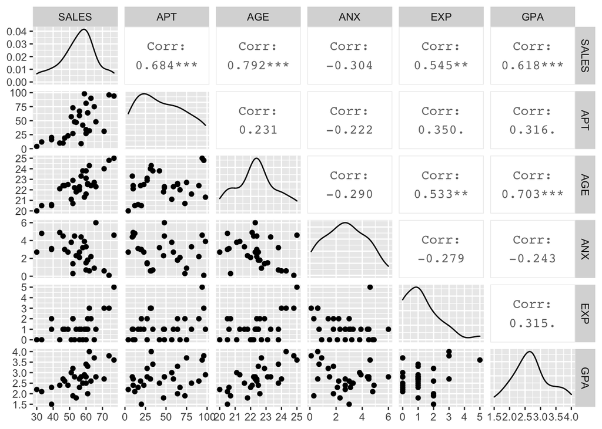

```r
ggpairs(data5)
```

# Model1

Since AGE has the highest correlation value, in the initial model I have added it as a predictor.

```r
model1 = lm(data5$SALES ~ data5$AGE)
summary(model1)
```

```
##
## Call:
## lm(formula = data5$SALES ~ data5$AGE)
##
## Residuals:
##     Min      1Q  Median      3Q     Max
## -9.2810 -6.6102  0.6617  4.7184 11.4048
##
## Coefficients:
##             Estimate Std. Error t value Pr(>|t|)
## (Intercept)  -98.335     22.428  -4.385 0.000149 ***
## data5$AGE      6.858      1.000   6.855  1.9e-07 ***
## ---
## Signif. codes:  0 '***' 0.001 '**' 0.01 '*' 0.05 '.' 0.1 ' ' 1
##
## Residual standard error: 6.904 on 28 degrees of freedom
## Multiple R-squared:  0.6266, Adjusted R-squared:  0.6133
## F-statistic: 46.99 on 1 and 28 DF,  p-value: 1.896e-07
```

### Iterations Model1

Then I have built every possible models which can be built by adding only one predictor. Comparing their anova results, I have realized that the one with the smallest p value was the one with APT as a regressor.

```r
model1.1= lm(data5$SALES ~ data5$AGE +data5$APT)
model1.2= lm(data5$SALES ~ data5$AGE +data5$ANX)
model1.3= lm(data5$SALES ~ data5$AGE +data5$EXP)
model1.4= lm(data5$SALES ~ data5$AGE +data5$GPA)

anova(model1 , model1.1)
```

```
## Analysis of Variance Table
##
## Model 1: data5$SALES ~ data5$AGE
## Model 2: data5$SALES ~ data5$AGE + data5$APT
##   Res.Df     RSS Df Sum of Sq      F Pr(>F)
## 1     28 1334.50
## 2     27  387.47  1    947.03 65.992  1e-08 ***
## ---
## Signif. codes:  0 '***' 0.001 '**' 0.01 '*' 0.05 '.' 0.1 ' ' 1
```

```r
anova(model1 , model1.2)
```

```
## Analysis of Variance Table
##
## Model 1: data5$SALES ~ data5$AGE
## Model 2: data5$SALES ~ data5$AGE + data5$ANX
##   Res.Df    RSS Df Sum of Sq      F Pr(>F)
## 1     28 1334.5
## 2     27 1312.5  1     21.98 0.4522  0.507
```

```r
anova(model1 , model1.3)
```

```
## Analysis of Variance Table
##
## Model 1: data5$SALES ~ data5$AGE
## Model 2: data5$SALES ~ data5$AGE + data5$EXP
##   Res.Df    RSS Df Sum of Sq      F Pr(>F)
## 1     28 1334.5
## 2     27 1259.4  1    75.128 1.6107 0.2152
```

```r
anova(model1 , model1.4)
```

```
## Analysis of Variance Table
##
## Model 1: data5$SALES ~ data5$AGE
## Model 2: data5$SALES ~ data5$AGE + data5$GPA
##   Res.Df    RSS Df Sum of Sq      F Pr(>F)
## 1     28 1334.5
## 2     27 1307.9  1    26.638 0.5499 0.4648
```

# Model2

Yielding model 2 is as follows

```r
model2 = lm(data5$SALES ~ data5$AGE + data5$APT)
summary(model2)
```

```
##
## Call:
## lm(formula = data5$SALES ~ data5$AGE + data5$APT)
##
## Residuals:
##    Min     1Q Median     3Q    Max
## -5.271 -2.275 -1.065  1.415 10.893
##
## Coefficients:
##             Estimate Std. Error t value Pr(>|t|)
## (Intercept) -83.8357    12.4356  -6.742 3.08e-07 ***
## data5$AGE     5.7969     0.5643  10.273 7.94e-11 ***
## data5$APT     0.2015     0.0248   8.124 1.00e-08 ***
## ---
## Signif. codes:  0 '***' 0.001 '**' 0.01 '*' 0.05 '.' 0.1 ' ' 1
##
## Residual standard error: 3.788 on 27 degrees of freedom
## Multiple R-squared:  0.8916, Adjusted R-squared:  0.8836
## F-statistic:   111 on 2 and 27 DF,  p-value: 9.404e-14
```

### Reducing Model2

I have tried to discard previous predictor, AGE in this case. After building a model (model2.r) without AGE, I have checked anova results of model2 and model2.r, from the results we can conclude that AGE variable is significant and we can benefit from it. It would best to keep it as a predictor.

```r
model2.r = lm(data5$SALES ~  data5$APT)

anova(model2, model2.r)
```

```
## Analysis of Variance Table
##
## Model 1: data5$SALES ~ data5$AGE + data5$APT
## Model 2: data5$SALES ~ data5$APT
##   Res.Df     RSS Df Sum of Sq      F    Pr(>F)
## 1     27  387.47
## 2     28 1902.00 -1   -1514.5 105.54 7.939e-11 ***
## ---
## Signif. codes:  0 '***' 0.001 '**' 0.01 '*' 0.05 '.' 0.1 ' ' 1
```

```r
#age is significant, keep it
```

### Iterations Model2

After building model2, I have added other predictor one by one and in order to check their significance I have printed the anova results of this models and our model2. It seems like no remaining possible predictors have an extra affect on the current prediction(model2), therefore I keep the model.

```r
model2 = lm(data5$SALES ~ data5$AGE + data5$APT)

model2.1= lm(data5$SALES ~ data5$AGE + data5$APT + data5$ANX)
model2.2= lm(data5$SALES ~ data5$AGE + data5$APT + data5$EXP)
model2.3= lm(data5$SALES ~ data5$AGE + data5$APT + data5$GPA)

anova(model2 , model2.1)
```

```
## Analysis of Variance Table
##
## Model 1: data5$SALES ~ data5$AGE + data5$APT
## Model 2: data5$SALES ~ data5$AGE + data5$APT + data5$ANX
##   Res.Df    RSS Df Sum of Sq     F Pr(>F)
## 1     27 387.47
## 2     26 387.27  1   0.19312 0.013 0.9102
```

```r
anova(model2 , model2.2)
```

```
## Analysis of Variance Table
##
## Model 1: data5$SALES ~ data5$AGE + data5$APT
## Model 2: data5$SALES ~ data5$AGE + data5$APT + data5$EXP
##   Res.Df    RSS Df Sum of Sq      F Pr(>F)
## 1     27 387.47
## 2     26 387.42  1  0.047057 0.0032 0.9556
```

```r
anova(model2 , model2.3)
```

```
## Analysis of Variance Table
##
## Model 1: data5$SALES ~ data5$AGE + data5$APT
## Model 2: data5$SALES ~ data5$AGE + data5$APT + data5$GPA
##   Res.Df    RSS Df Sum of Sq      F Pr(>F)
## 1     27 387.47
## 2     26 384.56  1    2.9087 0.1967 0.6611
```

# Using Step Function

In order to check my results, I have buil a step model where my direction is forward as it was in my manually built model. The result of this function is same as I have found, which is using AGE and APT in order to predict SALES.

```r
step( glm(SALES~1, family = gaussian , data = data5) , scope = SALES~ EXP + GPA + ANX + AGE + APT  , direction = "forward")
```

```
## Start:  AIC=232.55
## SALES ~ 1
##
##        Df Deviance    AIC
## + AGE   1   1334.5 204.99
## + APT   1   1902.0 215.62
## + GPA   1   2210.3 220.13
## + EXP   1   2513.8 223.99
## + ANX   1   3243.3 231.63
## <none>      3574.2 232.54
##
## Step:  AIC=204.99
## SALES ~ AGE
##
##        Df Deviance    AIC
## + APT   1   387.47 169.89
## <none>     1334.50 204.99
## + EXP   1  1259.37 205.25
## + GPA   1  1307.86 206.38
## + ANX   1  1312.52 206.49
##
## Step:  AIC=169.89
## SALES ~ AGE + APT
##
##        Df Deviance    AIC
## <none>      387.47 169.89
## + GPA   1   384.56 171.66
## + ANX   1   387.27 171.87
## + EXP   1   387.42 171.89
```

```
##
## Call:  glm(formula = SALES ~ AGE + APT, family = gaussian, data = data5)
##
## Coefficients:
## (Intercept)          AGE          APT
##    -83.8357       5.7969       0.2015
##
## Degrees of Freedom: 29 Total (i.e. Null);  27 Residual
## Null Deviance:       3574
## Residual Deviance: 387.5     AIC: 169.9
```

# Final Model

As found both from manually built model and the model built by using step() function, our final model is;

```r
model_final = lm(data5$SALES ~ data5$AGE + data5$APT )
summary(model_final)
```

```
##
## Call:
## lm(formula = data5$SALES ~ data5$AGE + data5$APT)
##
## Residuals:
##    Min     1Q Median     3Q    Max
## -5.271 -2.275 -1.065  1.415 10.893
##
## Coefficients:
##             Estimate Std. Error t value Pr(>|t|)
## (Intercept) -83.8357    12.4356  -6.742 3.08e-07 ***
## data5$AGE     5.7969     0.5643  10.273 7.94e-11 ***
## data5$APT     0.2015     0.0248   8.124 1.00e-08 ***
## ---
## Signif. codes:  0 '***' 0.001 '**' 0.01 '*' 0.05 '.' 0.1 ' ' 1
##
## Residual standard error: 3.788 on 27 degrees of freedom
## Multiple R-squared:  0.8916, Adjusted R-squared:  0.8836
## F-statistic:   111 on 2 and 27 DF,  p-value: 9.404e-14
```

### Estimates

Obtained from the summary of our final model, estimates are; Intercept -83.8357 AGE 5.7969 APT 0.2015 Residual Variance 14.3489

## Testing Hypotesis

In order to test wheter or not GPA data has an influence on SALES data based on my final model, I have added GPA data to my final model and checked the summary.

```r
model_hypotesis = lm(data5$SALES ~ data5$AGE + data5$APT + data5$GPA)
summary(model_hypotesis)
```

```
##
## Call:
## lm(formula = data5$SALES ~ data5$AGE + data5$APT + data5$GPA)
##
## Residuals:
##     Min      1Q  Median      3Q     Max
## -5.1466 -2.2892 -0.8423  1.5086 10.9757
##
## Coefficients:
##              Estimate Std. Error t value Pr(>|t|)
## (Intercept) -87.20756   14.73768  -5.917 3.05e-06 ***
## data5$AGE     6.03388    0.78345   7.702 3.58e-08 ***
## data5$APT     0.20404    0.02582   7.901 2.23e-08 ***
## data5$GPA    -0.75632    1.70548  -0.443    0.661
## ---
## Signif. codes:  0 '***' 0.001 '**' 0.01 '*' 0.05 '.' 0.1 ' ' 1
##
## Residual standard error: 3.846 on 26 degrees of freedom
## Multiple R-squared:  0.8924, Adjusted R-squared:   0.88
## F-statistic: 71.88 on 3 and 26 DF,  p-value: 1.028e-12
```

### Test

H0 -> GPA’s influence on SALES is equal to 0 H1 -> GPA’s influence on SALES is not equal to 0

a = 0.1 p-value = 0.661

Since our p-value is higher than 0.1, we fail to reject H0 this level of confidence.

# Conclusion

Our aim was to select appropriate predictors by testing a set of possible predictors, the two models which I have built manually and by using step() functions yields the same results. After ensuring the model was proper, I have tested if adding one more predictor (GPA) would make the model better by checking how much influance GPA have in the model. After doing so I have concluded that GDP data do not have a evidend extra affect.

# References

https://www.rdocumentation.org/packages/stats/versions/3.6.2/topics/step